# Análisis exploratorio

### 4. Responda las siguientes preguntas:

### 4.1. ¿Cuáles son las 10 películas que contaron con más presupuesto?

```r
# Seleccionar las 10 películas con mayor presupuesto
top_budget_movies <- movies %>%
  select(title, budget) %>%
  arrange(desc(budget)) %>%
  head(10)

# Mostrar las 10 películas con mayor presupuesto
cat("\n--- Las 10 películas con mayor presupuesto ---\n")
```

```
##
## --- Las 10 películas con mayor presupuesto ---
```

```r
print(top_budget_movies)
```

```
##                                          title    budget
## 1  Pirates of the Caribbean: On Stranger Tides 380000000
## 2                      Avengers: Age of Ultron 365000000
## 3                            Avengers: Endgame 356000000
## 4     Pirates of the Caribbean: At World's End 300000000
## 5                               Justice League 300000000
## 6                       Avengers: Infinity War 300000000
## 7                             Superman Returns 270000000
## 8                                      Tangled 260000000
## 9                                The Lion King 260000000
## 10                                Spider-Man 3 258000000
```

```r
# Análisis y conclusiones
cat("\n--- Análisis y Conclusiones ---\n")
```

```
##
## --- Análisis y Conclusiones ---
```

```r
# Resumen estadístico del presupuesto de estas películas
presupuesto_stats <- summary(top_budget_movies$budget)
print(presupuesto_stats)
```

```
##      Min.   1st Qu.    Median      Mean   3rd Qu.      Max.
## 258000000 262500000 300000000 304900000 342000000 380000000
```

```r
# Conclusiones
cat("- Estas películas tienen presupuestos significativamente altos en comparación con el promedio del dataset.\n")
```

```
## - Estas películas tienen presupuestos significativamente altos en comparación con el promedio del dataset.
```

```r
cat("- La película con el mayor presupuesto es:", top_budget_movies$title[1], "con un presupuesto de", top_budget_movies$budget[1], "USD.\n")
```

```
## - La película con el mayor presupuesto es: Pirates of the Caribbean: On Stranger Tides con un presupuesto de 380000000 USD.
```

```r
cat("- Estas producciones suelen corresponder a franquicias o estudios con alta inversión, lo que podría estar relacionado con mayores expectativas de ingresos.\n")
```

```
## - Estas producciones suelen corresponder a franquicias o estudios con alta inversión, lo que podría estar relacionado con mayores expectativas de ingresos.
```

```r
cat("- Este análisis ayuda a identificar tendencias en las películas más costosas y a analizar su desempeño financiero en relación con sus ingresos.\n")
```

```
## - Este análisis ayuda a identificar tendencias en las películas más costosas y a analizar su desempeño financiero en relación con sus ingresos.
```

### 4.2. ¿Cuáles son las 10 películas que más ingresos tuvieron?

```r
# Seleccionar las 10 películas con mayores ingresos
top_revenue_movies <- movies %>%
  select(title, revenue) %>%
  arrange(desc(revenue)) %>%
  head(10)

# Mostrar las 10 películas con mayores ingresos
cat("\n--- Las 10 películas con mayores ingresos ---\n")
```

```
##
## --- Las 10 películas con mayores ingresos ---
```

```r
print(top_revenue_movies)
```

```
##                           title    revenue
## 1                        Avatar 2847246203
## 2             Avengers: Endgame 2797800564
## 3                       Titanic 2187463944
## 4  Star Wars: The Force Awakens 2068223624
## 5        Avengers: Infinity War 2046239637
## 6                Jurassic World 1671713208
## 7                 The Lion King 1667635327
## 8       Spider-Man: No Way Home 1631853496
## 9                  The Avengers 1518815515
## 10                    Furious 7 1515047671
```

```r
# Análisis y conclusiones
cat("\n--- Análisis y Conclusiones ---\n")
```

```
##
## --- Análisis y Conclusiones ---
```

```r
# Resumen estadístico de los ingresos de estas películas
revenue_stats <- summary(top_revenue_movies$revenue)
print(revenue_stats)
```

```
##      Min.   1st Qu.    Median      Mean   3rd Qu.      Max.
## 1.515e+09 1.641e+09 1.859e+09 1.995e+09 2.158e+09 2.847e+09
```

```r
# Calcular la película con mayores ingresos
pelicula_mas_ingresos <- top_revenue_movies[1, ]
cat("- La película con los mayores ingresos es:", pelicula_mas_ingresos$title,
    "con un ingreso total de", pelicula_mas_ingresos$revenue, "USD.\n")
```

```
## - La película con los mayores ingresos es: Avatar con un ingreso total de 2847246203 USD.
```

```r
# Conclusiones
cat("- Las películas con los mayores ingresos suelen pertenecer a franquicias conocidas o contar con producciones de alto nivel.\n")
```

```
## - Las películas con los mayores ingresos suelen pertenecer a franquicias conocidas o contar con producciones de alto nivel.
```

```r
cat("- El rango de ingresos de estas películas es significativamente alto, indicando un éxito comercial sobresaliente.\n")
```

```
## - El rango de ingresos de estas películas es significativamente alto, indicando un éxito comercial sobresaliente.
```

```r
cat("- Este análisis permite identificar patrones en las películas más exitosas económicamente y su impacto en la industria cinematográfica.\n")
```

```
## - Este análisis permite identificar patrones en las películas más exitosas económicamente y su impacto en la industria cinematográfica.
```

### 4.3. ¿Cuál es la película que más votos tuvo?

```r
most_voted_movie <- movies %>%
  select(title, voteCount) %>%
  arrange(desc(voteCount)) %>%
  head(1)

# Mostrar la película con más votos
cat("\n--- Película con más votos ---\n")
```

```
##
## --- Película con más votos ---
```

```r
print(most_voted_movie)
```

```
##       title voteCount
## 1 Inception     30788
```

```r
# Análisis y conclusiones
cat("\n--- Análisis y Conclusiones ---\n")
```

```
##
## --- Análisis y Conclusiones ---
```

```r
# Detalles de la película con más votos
cat("- La película con más votos es:", most_voted_movie$title,
    "con un total de", most_voted_movie$voteCount, "votos.\n")
```

```
## - La película con más votos es: Inception con un total de 30788 votos.
```

```r
# Posibles razones para el alto número de votos
cat("- El alto número de votos puede estar relacionado con la popularidad general de la película, el elenco o la franquicia.\n")
```

```
## - El alto número de votos puede estar relacionado con la popularidad general de la película, el elenco o la franquicia.
```

```r
cat("- Es probable que esta película haya tenido una gran base de fans o una fuerte estrategia de marketing que impulsó su recepción en plataformas de votación.\n")
```

```
## - Es probable que esta película haya tenido una gran base de fans o una fuerte estrategia de marketing que impulsó su recepción en plataformas de votación.
```

```r
# Conclusión
cat("- Identificar películas con altos votos puede ayudar a entender qué características atraen a las audiencias y generan interacción.\n")
```

```
## - Identificar películas con altos votos puede ayudar a entender qué características atraen a las audiencias y generan interacción.
```

### 4.4. ¿Cuál es la peor película de acuerdo a los votos de todos los usuarios?

```r
# Seleccionar la peor película según el promedio de votos
worst_movie <- movies %>%
  select(title, voteAvg) %>%
  arrange(voteAvg) %>%
  head(1)

# Mostrar la peor película según los votos
cat("\n--- La peor película según el promedio de votos ---\n")
```

```
##
## --- La peor película según el promedio de votos ---
```

```r
print(worst_movie)
```

```
##                                                                              title
## 1 DAKAICHI -I'm Being Harassed by the Sexiest Man of the Year- The Movie: In Spain
##   voteAvg
## 1     1.3
```

```r
# Análisis y conclusiones
cat("\n--- Análisis y Conclusiones ---\n")
```

```
##
## --- Análisis y Conclusiones ---
```

```r
# Detalles de la película con la peor calificación
cat("- La peor película según el promedio de votos es:", worst_movie$title,
    "con un promedio de", worst_movie$voteAvg, "en la plataforma.\n")
```

```
## - La peor película según el promedio de votos es: DAKAICHI -I'm Being Harassed by the Sexiest Man of the Year- The Movie: In Spain con un promedio de 1.3 en la plataforma.
```

```r
# Posibles razones para la baja calificación
cat("- Las bajas calificaciones pueden deberse a problemas de calidad en la trama, actuaciones, dirección o simplemente a expectativas no cumplidas por parte del público.\n")
```

```
## - Las bajas calificaciones pueden deberse a problemas de calidad en la trama, actuaciones, dirección o simplemente a expectativas no cumplidas por parte del público.
```

```r
cat("- También podría tratarse de una producción menos popular, con menor presupuesto o limitada distribución.\n")
```

```
## - También podría tratarse de una producción menos popular, con menor presupuesto o limitada distribución.
```

```r
# Conclusión
cat("- Conocer las peores películas según los votos ayuda a identificar los factores que pueden generar una recepción negativa y evitar errores en futuras producciones.\n")
```

```
## - Conocer las peores películas según los votos ayuda a identificar los factores que pueden generar una recepción negativa y evitar errores en futuras producciones.
```

### 4.5. ¿Cuántas películas se hicieron en cada año? ¿En qué año se hicieron más películas? Haga un gráfico de barras

```r
# Calcular cuántas películas se hicieron en cada año
top_year_movies <- movies %>%
  mutate(releaseYear = as.numeric(substr(releaseDate, 1, 4))) %>% # Extraer el año de la fecha de lanzamiento
  group_by(releaseYear) %>%
  summarise(count = n()) %>%
  arrange(desc(count))

# Identificar el año con más películas
year_max_movies <- top_year_movies %>%
  filter(count == max(count))
cat("\n--- Año con más películas ---\n")
```

```
##
## --- Año con más películas ---
```

```r
cat("El año con más películas fue", year_max_movies$releaseYear, "con", year_max_movies$count, "películas.\n")
```

```
## El año con más películas fue 2021 con 816 películas.
```

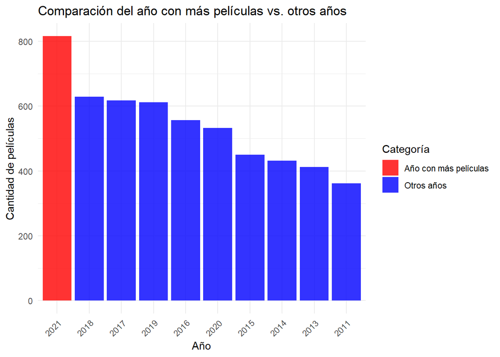

```r
# Seleccionar el año con más películas y otros 9 años con menos películas
comparison_years <- top_year_movies %>%
  filter(releaseYear != year_max_movies$releaseYear) %>%
  arrange(desc(count)) %>%
  head(9) %>%
  bind_rows(year_max_movies)

# Ordenar por número de películas (para gráfico más claro)
comparison_years <- comparison_years %>%
  arrange(desc(count))

# Crear indicador para resaltar el año con más películas
comparison_years <- comparison_years %>%
  mutate(Highlight = ifelse(releaseYear == year_max_movies$releaseYear, "Año con más películas", "Otros años"))

# Crear gráfico de barras
ggplot(comparison_years, aes(x = reorder(as.factor(releaseYear), -count), y = count, fill = Highlight)) +
  geom_bar(stat = "identity", alpha = 0.8) +
  scale_fill_manual(values = c("Año con más películas" = "red", "Otros años" = "blue")) +
  labs(title = "Comparación del año con más películas vs. otros años",
       x = "Año",
       y = "Cantidad de películas",
       fill = "Categoría") +
  theme_minimal() +
  theme(axis.text.x = element_text(angle = 45, hjust = 1))
```

```r
# Análisis y conclusiones
cat("\n--- Análisis y Conclusiones ---\n")
```

```
##
## --- Análisis y Conclusiones ---
```

```r
cat("- El año con más películas fue", year_max_movies$releaseYear, "con un total de", year_max_movies$count, "películas.\n")
```

```
## - El año con más películas fue 2021 con un total de 816 películas.
```

```r
cat("- Comparado con otros 9 años seleccionados, este año resalta significativamente por la cantidad de producciones.\n")
```

```
## - Comparado con otros 9 años seleccionados, este año resalta significativamente por la cantidad de producciones.
```

```r
cat("- Este gráfico destaca visualmente la diferencia entre este año y otros años con menos películas.\n")
```

```
## - Este gráfico destaca visualmente la diferencia entre este año y otros años con menos películas.
```

```r
cat("- Las razones para este auge en la producción pueden incluir avances tecnológicos, estrategias de mercado y una alta demanda del público.\n")
```

```
## - Las razones para este auge en la producción pueden incluir avances tecnológicos, estrategias de mercado y una alta demanda del público.
```

### 4.6. ¿Cuál es el género principal de las 20 películas más recientes? ¿Cuál es el género principal que predomina en el conjunto de datos? Represéntelo usando un gráfico. ¿A qué género principal pertenecen las películas más largas?

```r
# Extraer el año de la columna releaseDate
movies <- movies %>%
  mutate(releaseYear = as.numeric(substr(releaseDate, 1, 4)))

# Asegurarse de que el año de lanzamiento está disponible en el dataset
movies <- movies %>%
  mutate(releaseYear = as.numeric(substr(releaseDate, 1, 4)))

# 1. Identificar el género principal de las 20 películas más recientes
recent_movies <- movies %>%
  arrange(desc(releaseYear)) %>%
  head(20)

recent_genre_distribution <- table(recent_movies$genres)
recent_top_genre <- names(sort(recent_genre_distribution, decreasing = TRUE)[1])
cat("\n--- Género principal de las 20 películas más recientes ---\n")
```

```
##
## --- Género principal de las 20 películas más recientes ---
```

```r
print(recent_top_genre)
```

```
## [1] "Drama"
```

```r
# 2. Identificar el género principal en todo el conjunto de datos
genre_distribution <- table(movies$genres)
most_common_genre <- names(sort(genre_distribution, decreasing = TRUE)[1])
cat("\n--- Género principal que predomina en el conjunto de datos ---\n")
```

```
##
## --- Género principal que predomina en el conjunto de datos ---
```

```r
print(most_common_genre)
```

```
## [1] "Drama"
```

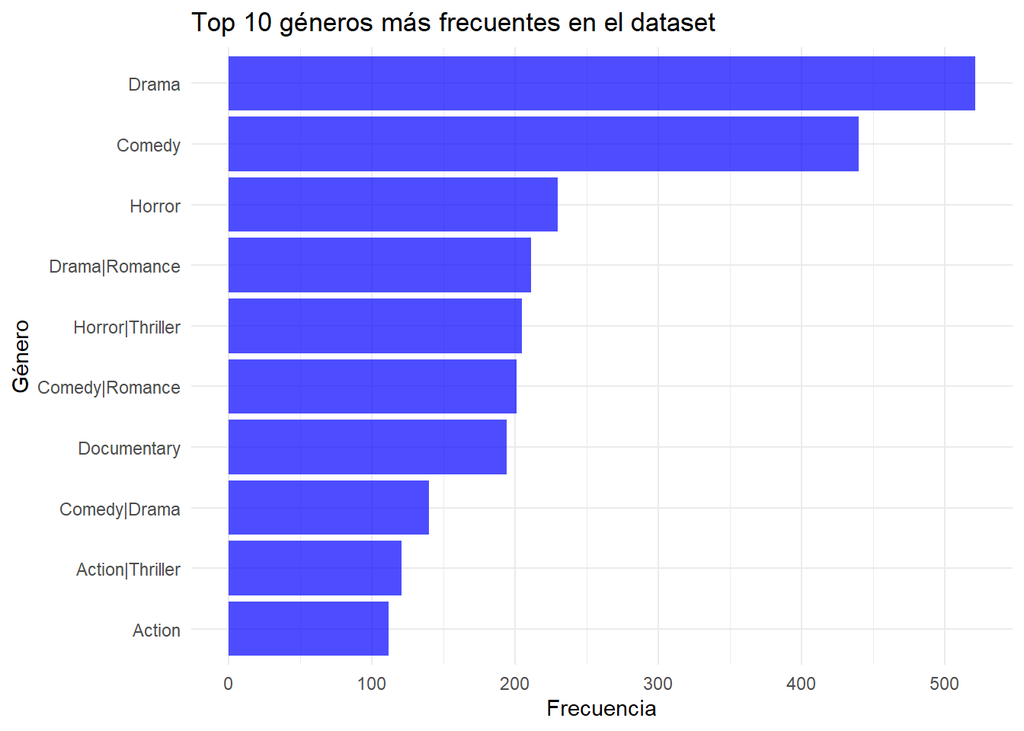

```r
# Crear gráfico para los 10 géneros más frecuentes en todo el dataset
top_genres <- sort(genre_distribution, decreasing = TRUE)[1:10]
top_genres_df <- data.frame(Género = names(top_genres), Frecuencia = as.vector(top_genres))

ggplot(top_genres_df, aes(x = reorder(Género, Frecuencia), y = Frecuencia)) +
  geom_bar(stat = "identity", fill = "blue", alpha = 0.7) +
  coord_flip() +
  labs(title = "Top 10 géneros más frecuentes en el dataset",
       x = "Género",
       y = "Frecuencia") +
  theme_minimal()
```

```r
# 3. Identificar el género principal de las películas más largas
longest_movies <- movies %>%
  arrange(desc(runtime)) %>%
  head(10)

longest_genre_distribution <- table(longest_movies$genres)
longest_top_genre <- names(sort(longest_genre_distribution, decreasing = TRUE)[1])
cat("\n--- Género principal de las películas más largas ---\n")
```

```
##
## --- Género principal de las películas más largas ---
```

```r
print(longest_top_genre)
```

```
## [1] "Documentary"
```

```r
# Análisis y conclusiones
cat("\n--- Análisis y Conclusiones ---\n")
```

```
##
## --- Análisis y Conclusiones ---
```

```r
cat("- El género principal de las 20 películas más recientes es:", recent_top_genre, ". Esto refleja tendencias actuales en la industria cinematográfica.\n")
```

```
## - El género principal de las 20 películas más recientes es: Drama . Esto refleja tendencias actuales en la industria cinematográfica.
```

```r
cat("- El género principal en todo el conjunto de datos es:", most_common_genre, ", lo que indica una preferencia general en la producción.\n")
```

```
## - El género principal en todo el conjunto de datos es: Drama , lo que indica una preferencia general en la producción.
```

```r
cat("- El género principal de las películas más largas es:", longest_top_genre, ". Esto sugiere que ciertos géneros requieren más tiempo de metraje para desarrollar historias complejas.\n")
```

```
## - El género principal de las películas más largas es: Documentary . Esto sugiere que ciertos géneros requieren más tiempo de metraje para desarrollar historias complejas.
```

```r
cat("- Visualizar los géneros más frecuentes permite entender qué tipos de películas dominan la industria y cómo evolucionan con el tiempo.\n")
```

```
## - Visualizar los géneros más frecuentes permite entender qué tipos de películas dominan la industria y cómo evolucionan con el tiempo.
```

### 4.7. ¿Las películas de qué genero principal obtuvieron mayores ganancias?

```r
# Cargar librerías necesarias
library(dplyr)

# Calcular las ganancias de cada película
movies <- movies %>%
  mutate(profit = revenue - budget) # Crear la columna de ganancias (profit)

# Calcular las ganancias totales por género
genre_profit <- movies %>%
  filter(genres != "") %>% # Filtrar géneros no vacíos
  group_by(genres) %>%
  summarise(total_profit = sum(profit, na.rm = TRUE)) %>% # Sumar ganancias por género
  arrange(desc(total_profit)) # Ordenar en orden descendente por ganancias

# Mostrar los 5 géneros con mayores ganancias
cat("\n--- Géneros con mayores ganancias ---\n")
```

```
##
## --- Géneros con mayores ganancias ---
```

```r
top_genre_profit <- head(genre_profit, 5)
print(top_genre_profit)
```

```
## # A tibble: 5 × 2
##   genres                           total_profit
##   <chr>                                   <dbl>
## 1 Action|Adventure|Science Fiction  14832790887
## 2 Comedy                            11692834444
## 3 Comedy|Romance                    10073967391
## 4 Drama                              9190582288
## 5 Adventure|Action|Science Fiction   8214486400
```

```r
# Identificar el género con mayores ganancias
top_genre <- top_genre_profit[1, ]
cat("\n--- Género con mayores ganancias ---\n")
```

```
##
## --- Género con mayores ganancias ---
```

```r
cat("El género con mayores ganancias es:", top_genre$genres,
    "con un total de", top_genre$total_profit, "USD.\n")
```

```
## El género con mayores ganancias es: Action|Adventure|Science Fiction con un total de 14832790887 USD.
```

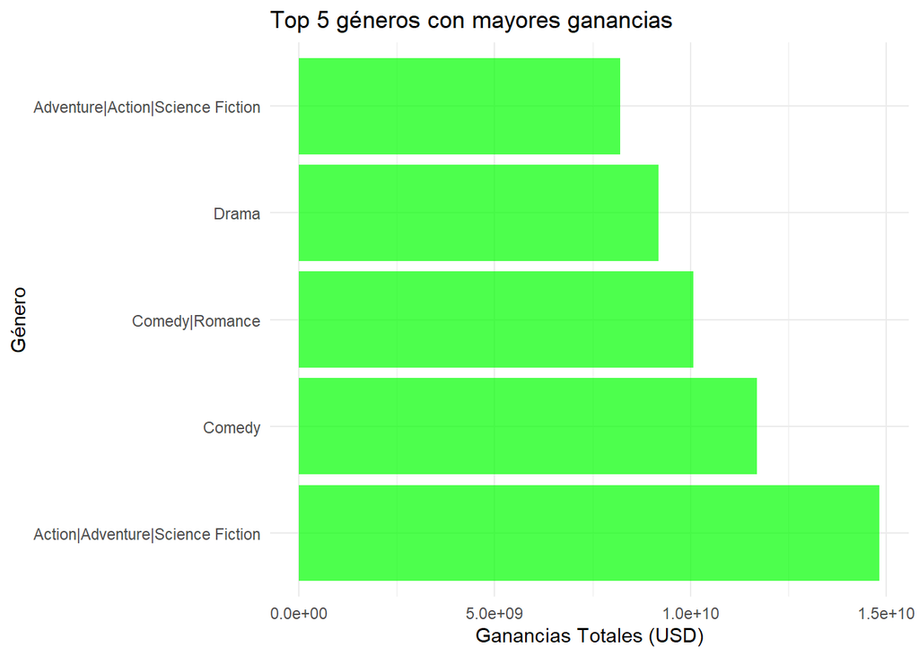

```r
# Crear un gráfico de los 5 géneros más rentables
ggplot(top_genre_profit, aes(x = reorder(genres, -total_profit), y = total_profit)) +
  geom_bar(stat = "identity", fill = "green", alpha = 0.7) +
  labs(title = "Top 5 géneros con mayores ganancias",
       x = "Género",
       y = "Ganancias Totales (USD)") +
  theme_minimal() +
  coord_flip()
```

```r
# Análisis y conclusiones
cat("\n--- Análisis y Conclusiones ---\n")
```

```
##
## --- Análisis y Conclusiones ---
```

```r
cat("- El género con mayores ganancias es:", top_genre$genres,
    "con un total de", top_genre$total_profit, "USD.\n")
```

```
## - El género con mayores ganancias es: Action|Adventure|Science Fiction con un total de 14832790887 USD.
```

```r
cat("- Los géneros más rentables suelen incluir producciones de alto presupuesto con gran éxito en taquilla.\n")
```

```
## - Los géneros más rentables suelen incluir producciones de alto presupuesto con gran éxito en taquilla.
```

```r
cat("- Este análisis permite identificar los géneros más lucrativos, lo que puede guiar decisiones estratégicas en producción y marketing.\n")
```

```
## - Este análisis permite identificar los géneros más lucrativos, lo que puede guiar decisiones estratégicas en producción y marketing.
```

```r
cat("- Visualizar las ganancias totales por género ayuda a priorizar inversiones en géneros con mayor potencial económico.\n")
```

```
## - Visualizar las ganancias totales por género ayuda a priorizar inversiones en géneros con mayor potencial económico.
```